# Flight Price

[figure not shown]

I've downloaded the dataset from: https://www.kaggle.com/datasets/shubhambathwal/flight-price-prediction?select=business.csv

The content of the dataset is the following:

**Features:**

The various features of the cleaned dataset are explained below:

- 1) Airline: The name of the airline company is stored in the airline column. It is a categorical feature having 6 different airlines.
- 2) Flight: Flight stores information regarding the plane's flight code. It is a categorical feature.
- 3) Source City: City from which the flight takes off. It is a categorical feature having 6 unique cities.
- 4) Departure Time: This is a derived categorical feature obtained created by grouping time periods into bins. It stores information about the departure time and have 6 unique time labels.
- 5) Stops: A categorical feature with 3 distinct values that stores the number of stops between the source and destination cities.
- 6) Arrival Time: This is a derived categorical feature created by grouping time intervals into bins. It has six distinct time labels and keeps information about the arrival time.
- 7) Destination City: City where the flight will land. It is a categorical feature having 6 unique cities.
- 8) Class: A categorical feature that contains information on seat class; it has two distinct values: Business and Economy.
- 9) Duration: A continuous feature that displays the overall amount of time it takes to travel between cities in hours.
- 10)Days Left: This is a derived characteristic that is calculated by subtracting the trip date by the booking date.
- 11) Price: Target variable stores information of the ticket price.

## Load of libraries that we're going to use

```python
import pandas as pd
import numpy as np
import sklearn
import matplotlib.pyplot as plt
import seaborn as sns
```

```python
Price_Airline = pd.read_csv('C:/Users/Usuario/Desktop/Dataset/Price_Airline.csv')
Price_Airline.head(5)
```

|  | Unnamed: 0 | airline | flight | source_city | departure_time | stops | arrival_time | destination_city | class | duration | days_left | price |
| --- | --- | --- | --- | --- | --- | --- | --- | --- | --- | --- | --- | --- |
| 0 | 0 | SpiceJet | SG-8709 | Delhi | Evening | zero | Night | Mumbai | Economy | 2.17 | 1 | 5953 |
| 1 | 1 | SpiceJet | SG-8157 | Delhi | Early_Morning | zero | Morning | Mumbai | Economy | 2.33 | 1 | 5953 |
| 2 | 2 | AirAsia | I5-764 | Delhi | Early_Morning | zero | Early_Morning | Mumbai | Economy | 2.17 | 1 | 5956 |
| 3 | 3 | Vistara | UK-995 | Delhi | Morning | zero | Afternoon | Mumbai | Economy | 2.25 | 1 | 5955 |
| 4 | 4 | Vistara | UK-963 | Delhi | Morning | zero | Morning | Mumbai | Economy | 2.33 | 1 | 5955 |

With the following code, we clean the duplicate data

```python
Price_Airline.drop_duplicates(inplace = True)
Price_Airline.shape
```

```
(300153, 12)
```

So, now we check info about our dataset

```python
Price_Airline.info()
```

```
<class 'pandas.core.frame.DataFrame'>
Int64Index: 300153 entries, 0 to 300152
Data columns (total 12 columns):
 #   Column            Non-Null Count   Dtype
---  ------            --------------   -----
 0   Unnamed: 0        300153 non-null  int64
 1   airline           300153 non-null  object
 2   flight            300153 non-null  object
 3   source_city       300153 non-null  object
 4   departure_time    300153 non-null  object
 5   stops             300153 non-null  object
 6   arrival_time      300153 non-null  object
 7   destination_city  300153 non-null  object
 8   class             300153 non-null  object
 9   duration          300153 non-null  float64
 10  days_left         300153 non-null  int64
 11  price             300153 non-null  int64
dtypes: float64(1), int64(3), object(8)
memory usage: 29.8+ MB
```

Drop the useless columns

```python
Price_Airline = Price_Airline.drop(columns=['Unnamed: 0'])
```

In the hist graph, we can see the variability of data about price column.

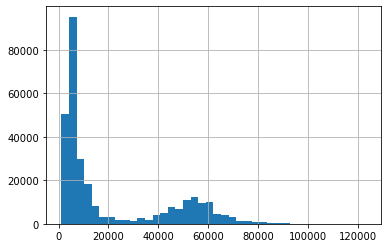

```python
Price_Airline.price.hist(bins = 40)
```

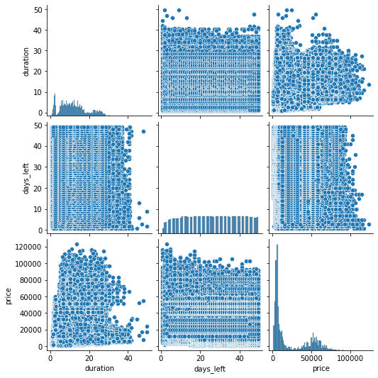

```python
sns.pairplot(Price_Airline, height=2.5)
plt.show()
```

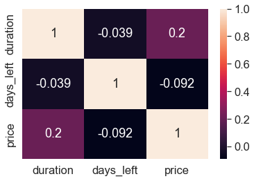

```python
numeric_cols = ['duration', 'days_left', 'price']
cm = np.corrcoef(Price_Airline[numeric_cols].values.T)
sns.set(font_scale=1.5)
sns.heatmap(cm,annot=True, yticklabels=numeric_cols,xticklabels=numeric_cols)
```

```python
Price_Airline = Price_Airline.rename(columns={'class': 'Class'})
```

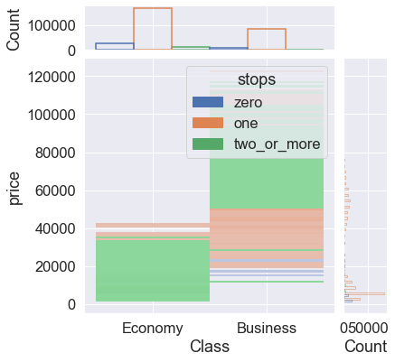

```python
sns.jointplot(data=Price_Airline, x='Class',y='price',hue='stops',kind='hist',marginal_ticks=True,
              marginal_kws=dict(bins=40,fill=False,multiple='dodge'))
plt.show()
```

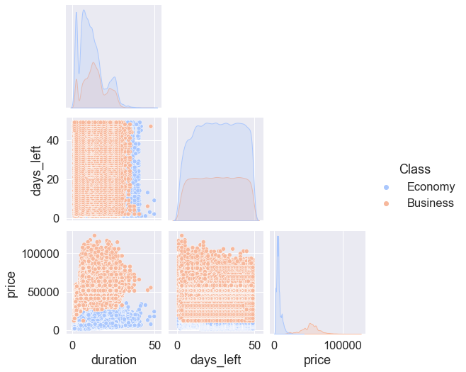

```python
sns.pairplot(data=Price_Airline,hue='Class',palette='coolwarm',corner=True,kind='scatter')
plt.show()
```

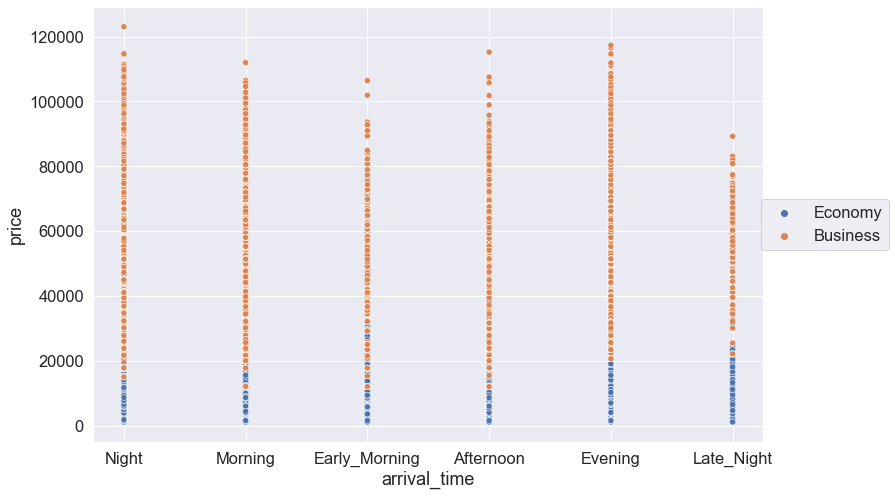

```python
plt.figure(figsize=(12,8))
sns.scatterplot(data=Price_Airline,x='arrival_time',y='price',hue='Class')
plt.legend(loc='right',bbox_to_anchor=(1.20,0.50))
plt.show()
```

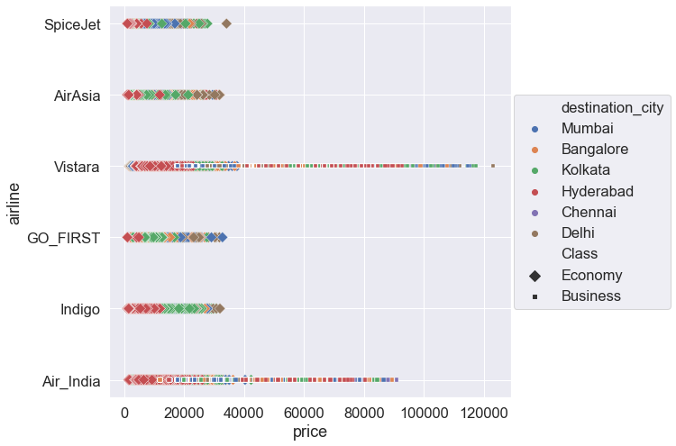

```python
plt.figure(figsize=(8,8))
markers = {"Economy":"D", "Business":"s"}
sns.scatterplot(data=Price_Airline,x='price',y='airline',hue='destination_city',style='Class',size='Class',markers=markers)
plt.legend(loc='center',bbox_to_anchor=(1.20,0.50))
plt.show()
```

```python
from sklearn.preprocessing import LabelEncoder
convert = LabelEncoder()
```

```python
Price_Airline.airline = Price_Airline.airline.apply(str)
Price_Airline.flight = Price_Airline.flight.apply(str)
Price_Airline.source_city = Price_Airline.source_city.apply(str)
Price_Airline.departure_time = Price_Airline.departure_time.apply(str)
Price_Airline.stops = Price_Airline.stops.apply(str)
Price_Airline.arrival_time = Price_Airline.arrival_time.apply(str)
Price_Airline.destination_city = Price_Airline.destination_city.apply(str)
Price_Airline.Class = Price_Airline.Class.apply(str)
```

```python
Price_Airline.insert(2, column = "num_airline", value = convert.fit_transform(Price_Airline.airline))
Price_Airline.insert(4, column = "num_flight", value = convert.fit_transform(Price_Airline.flight))
Price_Airline.insert(6, column = "num_source_city", value = convert.fit_transform(Price_Airline.source_city))
Price_Airline.insert(8, column = "num_departure_time", value = convert.fit_transform(Price_Airline.departure_time))
Price_Airline.insert(10, column = "num_stops", value = convert.fit_transform(Price_Airline.stops))
Price_Airline.insert(12, column = "num_arrival_time", value = convert.fit_transform(Price_Airline.arrival_time))
Price_Airline.insert(14, column = "num_destination_city", value = convert.fit_transform(Price_Airline.destination_city))
Price_Airline.insert(16, column = "num_Class", value = convert.fit_transform(Price_Airline.Class))
```

```python
Price_Airline.tail()
```

|  | airline | flight | num_airline | source_city | num_flight | departure_time | num_source_city | stops | num_departure_time | arrival_time | num_stops | destination_city | num_arrival_time | Class | num_destination_city | duration | num_Class | days_left | price |
| --- | --- | --- | --- | --- | --- | --- | --- | --- | --- | --- | --- | --- | --- | --- | --- | --- | --- | --- | --- |
| 300148 | Vistara | UK-822 | 5 | Chennai | 1477 | Morning | 1 | one | 4 | Evening | 0 | Hyderabad | 2 | Business | 3 | 10.08 | 0 | 49 | 69265 |
| 300149 | Vistara | UK-826 | 5 | Chennai | 1481 | Afternoon | 1 | one | 0 | Night | 0 | Hyderabad | 5 | Business | 3 | 10.42 | 0 | 49 | 77105 |
| 300150 | Vistara | UK-832 | 5 | Chennai | 1486 | Early_Morning | 1 | one | 1 | Night | 0 | Hyderabad | 5 | Business | 3 | 13.83 | 0 | 49 | 79099 |
| 300151 | Vistara | UK-828 | 5 | Chennai | 1483 | Early_Morning | 1 | one | 1 | Evening | 0 | Hyderabad | 2 | Business | 3 | 10.00 | 0 | 49 | 81585 |
| 300152 | Vistara | UK-822 | 5 | Chennai | 1477 | Morning | 1 | one | 4 | Evening | 0 | Hyderabad | 2 | Business | 3 | 10.08 | 0 | 49 | 81585 |

```python
Price_Airline = Price_Airline.drop(columns=['airline','flight','source_city','departure_time','stops','arrival_time','destination_city',
                                                           'Class'])
```

```python
from sklearn.preprocessing import StandardScaler
from sklearn.linear_model import LinearRegression
from sklearn.model_selection import train_test_split
```

```python
y = Price_Airline["price"]
X = Price_Airline.drop(columns=["price"])
```

```python
y.head(5)
```

```
0    5953
1    5953
2    5956
3    5955
4    5955
Name: price, dtype: int64
```

```python
X.head(5)
```

|  | num_airline | num_flight | num_source_city | num_departure_time | num_stops | num_arrival_time | num_destination_city | duration | num_Class | days_left |
| --- | --- | --- | --- | --- | --- | --- | --- | --- | --- | --- |
| 0 | 4 | 1408 | 2 | 2 | 2 | 5 | 5 | 2.17 | 1 | 1 |
| 1 | 4 | 1387 | 2 | 1 | 2 | 4 | 5 | 2.33 | 1 | 1 |
| 2 | 0 | 1213 | 2 | 1 | 2 | 1 | 5 | 2.17 | 1 | 1 |
| 3 | 5 | 1559 | 2 | 4 | 2 | 0 | 5 | 2.25 | 1 | 1 |
| 4 | 5 | 1549 | 2 | 4 | 2 | 4 | 5 | 2.33 | 1 | 1 |

```python
X_train, X_test, y_train, y_test = train_test_split(X, y, test_size = 0.25, random_state = 0)
```

```python
X_train.shape
```

```
(225114, 10)
```

```python
X_test.shape
```

```
(75039, 10)
```

```python
y_train.shape
```

```
(225114,)
```

```python
y_test.shape
```

```
(75039,)
```

```python
lr = LinearRegression()
```

```python
lr.fit(X_train, y_train)
```

```
LinearRegression()
```

```python
y_pred_lr = lr.predict(X_test)
```

```python
from sklearn.metrics import mean_squared_error
from math import sqrt
```

```python
sqrt(mean_squared_error(y_test, y_pred_lr))
```

```
6959.037817217827
```

```python
import sklearn.metrics as metrics
```

```python
metrics.median_absolute_error(y_test, y_pred_lr)
```

```
2978.242957728158
```

```python
metrics.r2_score(y_test, y_pred_lr)
```

```
0.9056968849099274
```

```python
import joblib
```

```python
joblib.dump(lr, 'Modelo_PA.pkl')
```

```
['Modelo_PA.pkl']
```

```python
from joblib import load
```

```python
Regression_model = load('Modelo_PA.pkl')
print(Regression_model)
```

```
LinearRegression()
```

The main objective of this dataset, it's apply a prediction about price of a flight, depending of the airline. Once, We applied our algorithm about regression, we can predict about the price of a flight of a company taking in considering the distintc feature according to dataset.

```python
prediction = Regression_model.predict([[4,1408,2,2,2,5,5,2.17,1,1],[5,1483,1,1,0,2,3,10,0,49]])
print(prediction)
```

```
[ 5302.95226962 50724.39853299]
```

**Result:** As result of our model, as example we predict the price of a flight with two samples.

```python
prediction = [round(price) for price in prediction]
print(prediction)
```

```
[5303, 50724]
```